# **After the storm: Community composition and diversity shifts after a hemlooper looper outbreak (*Lambdina fiscellaria*) on Anticosti Island, 1973**

#### Living Data Project - Maxime Fraser Franco (UQAM) and Victoria Marie Glynn (McGill)

Using real data from a devastating pest outbreak in Québec, we will begin to explore how **disturbance** in ecological communities impact:

- community composition
- diversity metrics
- species abundance curves

When you think of predator-prey interactions, what comes to mind? Perhaps it is the emblematic hare and lynx example from the [Hudson’s Bay Company pelt-trading dataset](https://jckantor.github.io/CBE30338/02.05-Hare-and-Lynx-Population-Dynamics.html), or footage from nature documentaries that show lions hunting zebras. But predator-prey interactions are often less conspicuous, and still strongly impact ecological communities. A great example are insect pests and their plant prey. In this tutorial, we are going to explore an instance of this interaction on Anticosti Island, Québec, between the hemlooper looper (*Lambdina fiscellaria*) and the trees it predates upon, and how this can reverberate throughout the greater beetle and lepidoptera community.

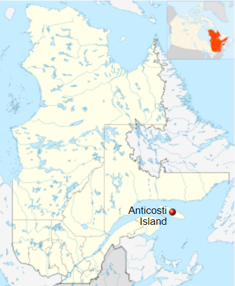

Map of Anticosti Island, Québec

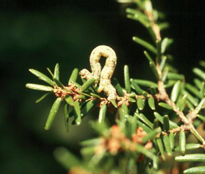

Hemlock looper larvae on a tree branch

## **1. Getting to know our data**

### Let us begin by loading in the two datasets:

#### First, let us call in the tree composition dataset, which we will call ‘tree’

```r
tree <- read.csv("anticosti_1973_trees.csv", header = TRUE)
```

#### Next, let us call in the beetle and lepidoptera biodiversity dataset, which we will call ‘insect’

```r
insect <- read.csv("microsigebready_carabeslepidoptera_anticosti_1993_en.csv", header = TRUE)
```

Before beginning our analyses, it is great practice to quickly inspect the data and ask ourselves, is all the information we are looking for there?

A quick first visualization we can do is to see the tree diversity per compartment:

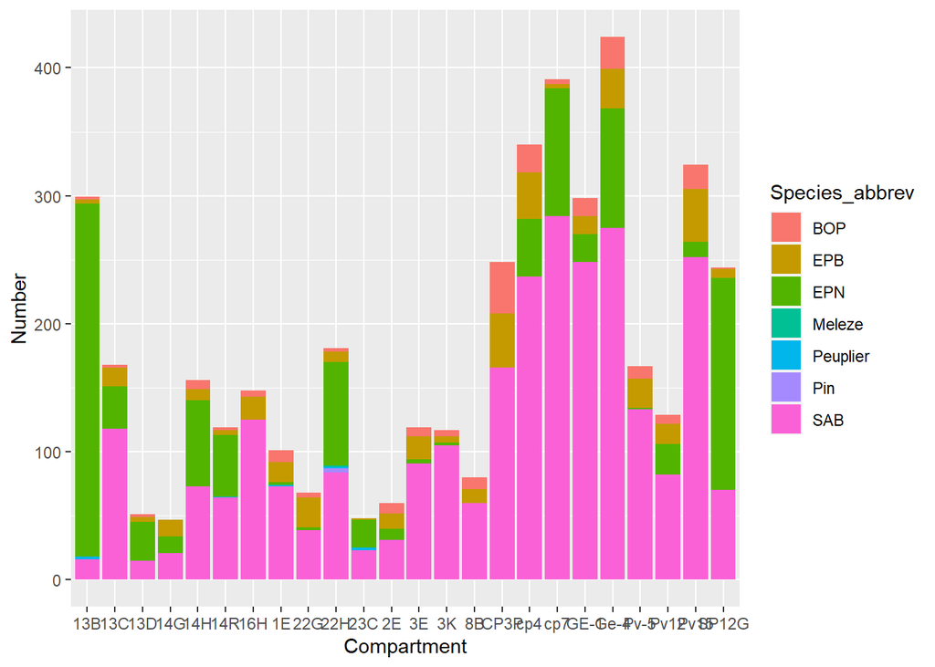

```r
##diversity of trees per compartment

library(ggplot2)

treediv <- ggplot(tree, aes (y=Number, x=Compartment, fill = Species_abbrev)) +
    geom_bar(position="stack", stat="identity")

treediv
```

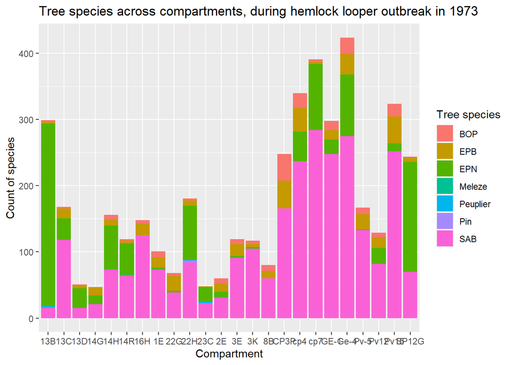

```r
##Further customize tree plot

library(ggplot2)
library(viridis)
library(hrbrthemes)
cbPalette <- c("#999999", "#E69F00", "#56B4E9", "#009E73", "#F0E442", "#0072B2", "#D55E00", "#CC79A7")

treediv_cus <- treediv +  scale_fill_manual(values=cbPalette) +
    ggtitle("Tree species across compartments, during hemlock looper outbreak in 1973") +
    xlab("Compartment") + ylab ("Count of species") + scale_fill_discrete(name = "Tree species")
treediv_cus
```

```r
ggsave("treediv_cus.png", width = 10, height = 5)
```

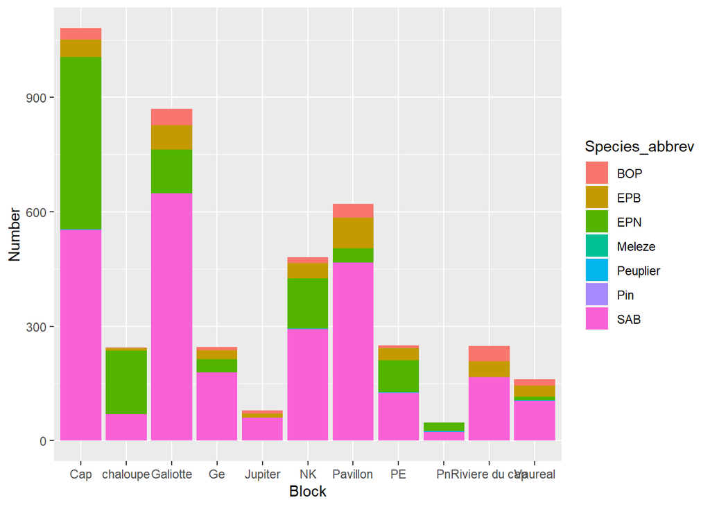

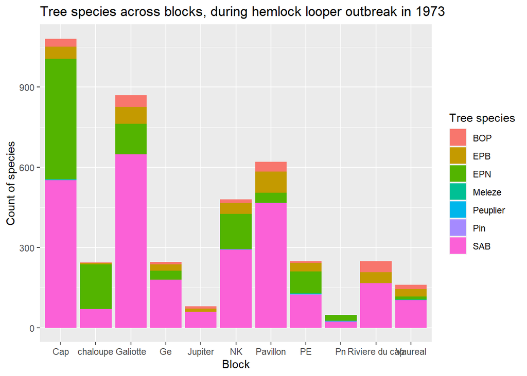

As we know these trees were sampled during a hemlock looper outbreak, we can now ask: how were different tree species affected?

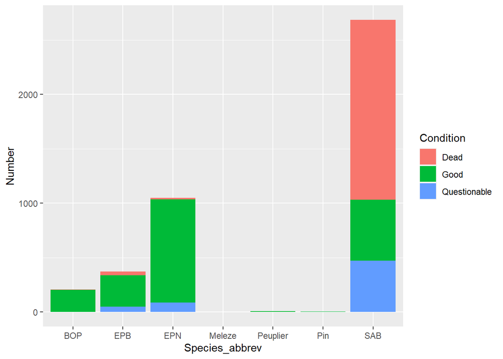

```r
## Differences in tree condition per plot

##diversity of trees per compartment

treecon <- ggplot(tree, aes (y=Number, x=Species_abbrev, fill = Condition)) +
    geom_bar(position="stack", stat="identity")

treecon
```

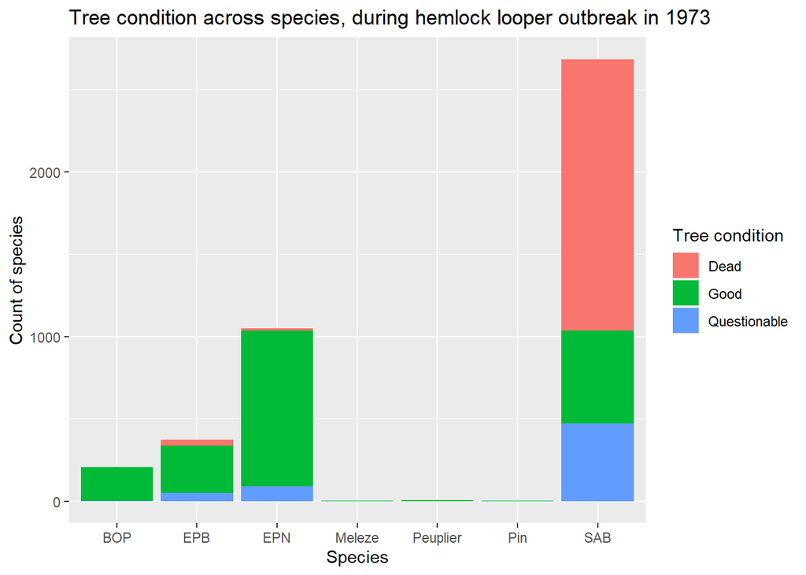

```r
cbPalette <- c("#999999", "#E69F00", "#56B4E9", "#009E73", "#F0E442", "#0072B2", "#D55E00", "#CC79A7")

treecon_2 <- treecon + scale_fill_manual(values=cbPalette) +
    ggtitle("Tree condition across species, during hemlock looper outbreak in 1973") +
    xlab("Species") + ylab ("Count of species") + scale_fill_discrete(name = "Tree condition")
treecon_2
```

```r
ggsave("treecon_2.png", dpi = 320)
```

## **2. Species accumulation curves**

- general characteristics
- assumptions?

BIG ONE HERE is that we can obtain a count of all the species present > sampling effort

Is it reasonable to have been able to count all species on Anticosti Island, in a given 400 m^2 plot?

[Paper] (https://besjournals.onlinelibrary.wiley.com/doi/10.1046/j.1365-2656.2003.00748.x)

[figure not shown]

```r
plot(sp2a_full$sites, sp2a_full$richness, xlab="Number of Sites",ylab="Species Richness", main="Tree species accumulation curve, Anticosti Island 1973", ylim = c(5,9), na.rm=TRUE)
```

```r
library(plyr)
ddply(block_condition,~Block,function(x) {
+  data.frame(RICHNESS=sum(x[-1]>0))
})
```

```
##             Block RICHNESS
## 1             Cap        5
## 2        chaloupe        4
## 3        Galiotte        4
## 4              Ge        4
## 5         Jupiter        3
## 6              NK        5
## 7        Pavillon        4
## 8              PE        7
## 9              Pn        4
## 10 Riviere du cap        3
## 11        Vaureal        5
```

[figure not shown]

```r
plot(sp2a$sites, sp2a$richness, xlab="Number of Sites",ylab="Species Richness", main="Tree species accumulation curve, trees with good condition - Anticosti Island 1973", ylim = c(5,9), na.rm=TRUE)
```

The variability in the shape of SACs is primarily due to variations in the catchable/trappable fauna assemblage structure, which can occur due to variations in ambient temperature, and among seasons and from year-to-year

[output not shown]